# 36-315 Lab 03

Eu Jing Chua

Due Friday, Sept 13, 2019 (6:30pm)

## Lab 03 (Analyze This!): 1-D, 2-D, and 3-D Categorical Graphics

Using the tidyverse style guide.

# Problem 1

(5 points each)

**Chi-Square Tests in R**:

```r
library(tidyverse)

# reads Matey's IMDb rated movies TV Series, etc.
mateys_imdb <- read_csv("https://raw.githubusercontent.com/mateyneykov/315_code_data/master/data/mateys_imdb_ratings.csv")

# filters only Featured Films
mateys_movies <- mateys_imdb %>% filter(`Title type` == "Feature Film")
```

```r
mateys_movies %>% group_by(Directors) %>% summarize(count = n()) %>%
  filter(count == max(count))
```

```
## # A tibble: 3 x 2
##   Directors         count
##   <chr>             <int>
## 1 Christopher Nolan     9
## 2 David Fincher         9
## 3 Martin Scorsese       9
```

The above code finds the counts of movies by each director. The filter removes all rows that are not the maximum count of 9.

```r
mateys_movies <- mutate(mateys_movies,
                    vote_date = as.Date(mateys_movies$created,
                                format = "%a %b %d %H:%M:%S %Y"),
                    day_of_week = weekdays(vote_date),
                    weekend = ifelse(day_of_week %in% c("Saturday", "Sunday"),
                                     "Weekend", "Workday"),
                    duration = cut(`Runtime (mins)`, c(0, 90, 120, Inf),
                                        labels = c("Short", "Medium", "Long")),
                    ratings = cut(`You rated`, c(0, 4, 7, Inf),
                                  labels = c("Low", "Med", "High")),
                    movie_period = cut(Year, c(0, 1980, 2000, 2018),
                              labels = c("Old", "Recent", "New"))
)
```

```r
#  Get counts, proportions, and percentages for duration
duration_marginal <- mateys_movies %>%
  group_by(duration) %>%
  summarize(count = n(),
            total = nrow(mateys_movies),
            proportion = round(count / total, 4),
            percentage = proportion * 100)

movie_period_marginal <- mateys_movies %>%
    group_by(movie_period) %>%
    summarize(count = n(),
              total = nrow(mateys_movies),
              proportion = round(count / total, 4),
              percentage = proportion * 100)
```

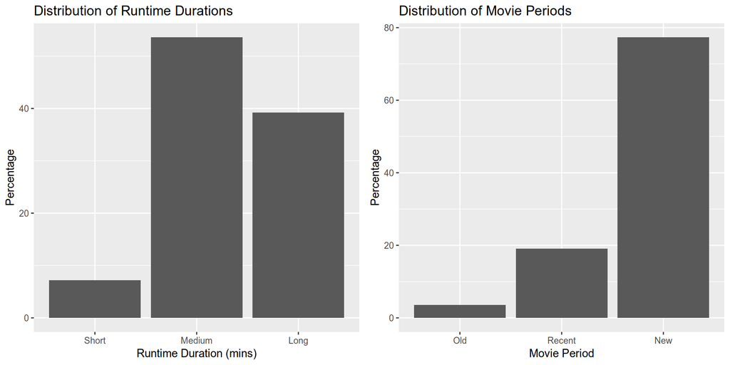

```r
library(gridExtra)  #  Be sure this is installed on your computer
library(ggplot2)
duration_plot <- ggplot(duration_marginal, aes(x = duration, y = percentage)) +
  geom_bar(stat = "identity") +
  labs(x = "Runtime Duration (mins)",
       y = "Percentage",
       title = "Distribution of Runtime Durations")

movie_period_plot <- ggplot(movie_period_marginal,
                            aes(x = movie_period, y = percentage)) +
                        geom_bar(stat = "identity") +
                        labs(x = "Movie Period",
                             y = "Percentage",
                             title = "Distribution of Movie Periods")

grid.arrange(duration_plot, movie_period_plot, ncol = 2)
```

4. My friend is probably wrong, and I am quite certain but cannot quantify it just by looking at the plot.

```r
chisq.test(duration_marginal$count)
```

```
##
##  Chi-squared test for given probabilities
##
## data:  duration_marginal$count
## X-squared = 249.5196744, df = 2, p-value < 2.220446e-16
```

The test output shows the test statistic, the degrees of freedom, and the p-value of 2.2e-16. This is much smaller than a significance level of 0.05, so we reject the null hypothesis and conclude the proportions are different, so my friend is wrong.

```r
chisq.test(duration_marginal$count, p = c(0.075, 0.525, 0.4))
```

```
##
##  Chi-squared test for given probabilities
##
## data:  duration_marginal$count
## X-squared = 0.3762680106, df = 2, p-value = 0.828503676
```

My friend’s revised guess is not wrong, as we failed to reject the null hypothesis in this case (p-value = 0.8285) as our evidence did not strongly counter the null.

7. BONUS (2 points):

The chi-square test assumes the measurements are nominal or ordinal in nature.

# Problem 2

(10 points each)

**2-D Bar Charts and (Empirical) Conditional Distributions**

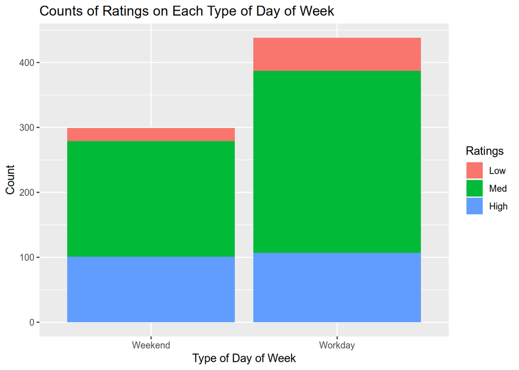

```r
ggplot(mateys_movies, aes(x = weekend, fill = ratings)) +
    geom_bar() +
    labs(x = "Type of Day of Week",
         y = "Count",
         title = "Counts of Ratings on Each Type of Day of Week",
         fill = "Ratings")
```

2. The plot shows that the count of high ratings do not differ much between weekends and workdays.

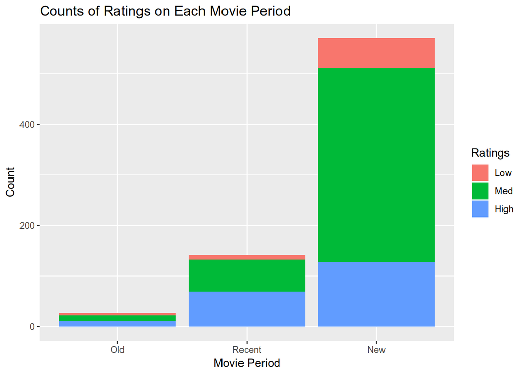

```r
ggplot(mateys_movies, aes(x = movie_period, fill = ratings)) +
    geom_bar() +
    labs(x = "Movie Period",
         y = "Count",
         title = "Counts of Ratings on Each Movie Period",
         fill = "Ratings")
```

4. The total counts of movies in each movie period has been increasing, but it is hard to tell if the proportions of each rating has changed over the periods.

# Problem 3

(10 points each)

**3-D and 4-D Categorical Data**

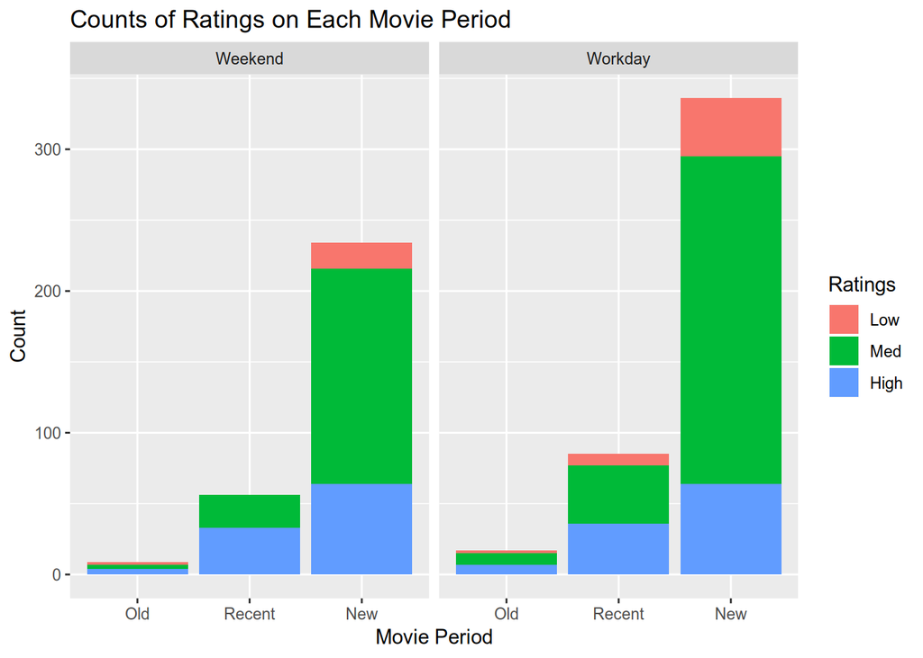

```r
ggplot(mateys_movies, aes(x = movie_period, fill = ratings)) +
    facet_wrap(~ weekend) +
    geom_bar() +
    labs(x = "Movie Period",
         y = "Count",
         title = "Counts of Ratings on Each Movie Period",
         fill = "Ratings")
```

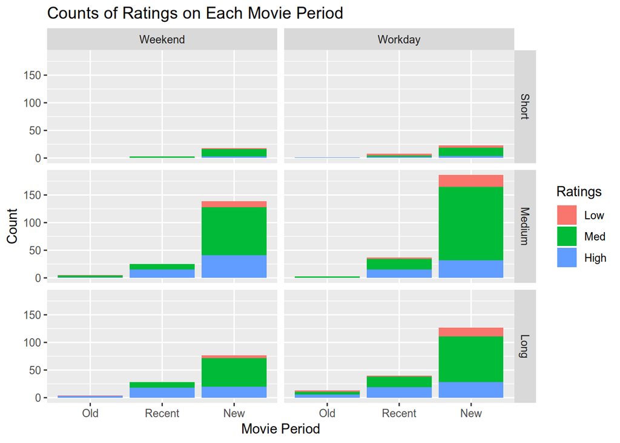

```r
ggplot(mateys_movies, aes(x = movie_period, fill = ratings)) +
    facet_grid(duration ~ weekend) +
    geom_bar() +
    labs(x = "Movie Period",
         y = "Count",
         title = "Counts of Ratings on Each Movie Period",
         fill = "Ratings")
```

From the first plot, it can been seen that the number of high ratings across each movie period does not vary much between a weekend and a workday, despite there being more observations on workdays than weekends in general.

It is also interesting to note that the patterns observed in the first plot are still roughly observered in each facet of duration in the second plot, where the same pattern roughly applies across different durations of movies, but with there being much less observations for short movies in general.